# Análise de Risco de Sinistros Residenciais com Machine Learning: Um Estudo de Teste de Hipótese - A/B

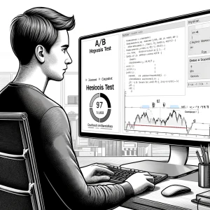

# 1. Introdução

Neste projeto, investigaremos os fatores que contribuem para o risco de sinistros em apólices de seguros residenciais. O objetivo é identificar padrões e correlações entre variáveis que possam ajudar a entender e prever o risco de sinistros, permitindo que a seguradora tome medidas proativas para mitigar esses riscos.

# 2. Contexto

A seguradora enfrenta desafios constantes em relação aos sinistros em apólices residenciais. Identificar os fatores que influenciam o risco de sinistros pode ajudar a precificar adequadamente as apólices, implementar medidas preventivas e melhorar a experiência do cliente.

# 3. Problema Proposto

Analisar os dados de sinistros em apólices residenciais para identificar os principais fatores que contribuem para o risco de sinistros.

# 4. Metodologia

- Coleta e preparação dos dados.
- Análise exploratória dos dados.
- Teste de hipótese para identificar correlações significativas entre variáveis e o risco de sinistros.
- Criação de modelos de machine learning para prever o risco de sinistros.

# 5. Configuração de Ambiente e Importação de Bibliotecas

## Preparação do Ambiente de Análise

Inicializa o ambiente de análise carregando todas as bibliotecas necessárias para manipulação de dados, análise estatística e visualização, garantindo que todas as ferramentas estejam disponíveis para as etapas subsequentes.

```python
# Importação das bibliotecas essenciais para manipulação de dados
import pandas as pd
import numpy as np

# Bibliotecas para visualização de dados
import seaborn as sns
import matplotlib.pyplot as plt

# Bibliotecas para análise estatística
from scipy.stats import ttest_ind

# Bibliotecas para machine learning
from sklearn.model_selection import train_test_split, GridSearchCV
from sklearn.linear_model import LogisticRegression
from sklearn.metrics import classification_report, confusion_matrix
from sklearn.pipeline import Pipeline
from sklearn.preprocessing import StandardScaler, OneHotEncoder
from sklearn.compose import ColumnTransformer
from sklearn.impute import SimpleImputer  # Importando SimpleImputer

import os
from IPython.display import display, Markdown, HTML

# Configuração estética dos gráficos do seaborn
sns.set(style="whitegrid")
```

# 6. Carregamento de Dados

## 6.1. Carregamento e Inspeção Inicial dos Dados

Os dados são carregados para a memória. Realiza-se uma inspeção inicial para verificar a integridade e estrutura básica do conjunto de dados.

```python
# Obtendo o caminho para a área de trabalho do usuário atual com a substituição de barras para compatibilidade
desktop_path = os.path.join(os.path.expanduser('~'), 'Desktop').replace('\\', '/')

# Construir o caminho para o arquivo com barras corretas
file_path = os.path.join(desktop_path, 'seguro', 'dados_seguro_residencial.csv').replace('\\', '/')

try:
    dados = pd.read_csv(file_path, delimiter=';', encoding='utf-8')

    display(Markdown("<h3 style='color: darkred'>Arquivo .CVS lido com sucesso!!</h3>"))

except FileNotFoundError:
    display(Markdown("<h3 style='color: darkred'>Não foi possível carregar o arquivo!!</h3>"))
```

Arquivo .CVS lido com sucesso!!

## 6.2. Exibindo as primeiras linhas do DataFrame para inspeção inicial

```python
dados.head()
```

|  | id_imovel,loc_resid,idade_prop,valor_imovel,tipo_construcao,hist_sinistro,valor_p_seguro,Sinistro,regiao,idade_prop.1 |
| --- | --- |
| 0 | 391,Porto Alegre,49.16887653104069,216934.2607... |
| 1 | 568,Vitória,43.29865578035664,50000.0,Apartame... |
| 2 | 390,Porto Alegre,53.43275293906032,428600.8649... |
| 3 | 71,Belo Horizonte,36.52013784894929,476034.882... |
| 4 | 663,João Pessoa,61.65378370551321,261840.98521... |

## 6.3. Visão Geral dos Dados

```python
# Exibindo informações da quantidade de registros e colunas

display(Markdown(f"<h3 style='color: darkblue'> Verificamos a existência de {dados.shape[0]} observações e {dados.shape[1]} colunas no DataSet. "))
```

Verificamos a existência de 1000 observações e 1 colunas no DataSet.

## 6.4. Apresenta Metadados de Cada Variável:

[output not shown]

## 6.5. Análise de dados faltantes

```python
# Calcula o total e a porcentagem de dados faltantes por coluna

total_faltantes = dados.isnull().sum()
percentual_faltantes = (dados.isnull().mean() * 100)

# Criar um DataFrame para a tabela resumida

tabela_resumo_faltantes = pd.DataFrame({
    'Coluna': total_faltantes.index,

    'Dados Faltantes': total_faltantes.values,

    'Percentual (%)': percentual_faltantes.values
})

# Ordenar a tabela pelo número de dados faltantes

tabela_resumo_faltantes = tabela_resumo_faltantes.sort_values(by='Dados Faltantes', ascending=False)

display(Markdown("<h3 style='color: darkblue'>Tabela Resumo de Dados Faltantes</h3>"))

# Exibi a tabela resumida

print(tabela_resumo_faltantes)
```

Tabela Resumo de Dados Faltantes

```
                                              Coluna  Dados Faltantes  \
0  id_imovel,loc_resid,idade_prop,valor_imovel,ti...                0

   Percentual (%)
0             0.0
```

## 6.6. Análise de Dados Duplicados

```python
# Conta o número de registros duplicados
numero_duplicados = dados.duplicated().sum()

# calcula a porcentagem de duplicatas em relação ao total
total_registros=len(dados)
percentual_duplicados = (numero_duplicados / total_registros) * 100

if numero_duplicados > 0:
    display(Markdown(f"<h3 style='color: darkred'>Foram encontrados {numero_duplicados} registros duplicados, representando {percentual_duplicados:.2f}% do total de {dados.shape[0]} registros!</h3>"))
else:
    display(Markdown("<h2 style='color: red'>Não foram encontrados dados duplicados no conjunto de dados</h2>"))


print()
```

Não foram encontrados dados duplicados no conjunto de dados

# 7. Pré-processamento dos Dados

## Limpeza e Preparação dos Dados

```python
total_faltantes = dados.isnull().sum().any()

if total_faltantes > 0:

    # Imputação para dados faltantes no 'valor_p_seguro' considerando 'tipo_construcao' e 'valor_imovel'

    # Ordenar dados para melhor visualização e consistência no processo de imputação

    dados.sort_values(by=['tipo_construcao', 'valor_imovel'], inplace=True)

    # Definindo função para imputação dentro dos grupos

    def impute_within_group(group):
        if group.isnull().all():

            return group

        imputer = SimpleImputer(strategy='median')

        return imputer.fit_transform(group.values.reshape(-1, 1)).ravel()  # Use ravel() para converter array 2D para 1D

    # Ordenar dados para melhor visualização e consistência no processo de imputação
    dados.sort_values(by=['tipo_construcao', 'valor_imovel'], inplace=True)

    # Aplicando a imputação agrupada
    dados['valor_p_seguro'] = dados.groupby(['tipo_construcao', pd.cut(dados['valor_imovel'], bins=3)])['valor_p_seguro'] \
                                .transform(lambda x: impute_within_group(x))

    # Verificação e limpeza final
    # Remover quaisquer linhas que ainda tenham valores faltantes após a imputação, se necessário
    dados.dropna(inplace=True)

else:
    print("Sem dados faltantes para imputação")
```

```
Sem dados faltantes para imputação
```

# 8. Análise Exploratória de Dados

## Exploração e Visualização dos Dados

Explora as características principais dos dados, buscando padrões, anomalias e correlações entre as variáveis.

## 8.1 Visualizando da Distribuição da Idade dos Proprietários

```python
# Histograma simplificado da idade dos proprietários
plt.figure(figsize=(12, 6))

bins_valor = range(20, 81, 5)  # Definindo bins de 20 a 80 com passo de 5

histograma = sns.histplot(dados['idade_prop'], bins=30, color='skyblue', edgecolor='black')

# Agora, ajustando os limites do eixo Y conforme a frequência máxima
max_height = histograma.patches[0].get_height()  # Começa com a altura da primeira barra

for patch in histograma.patches:

    if patch.get_height() > max_height:

        max_height = patch.get_height()  # Encontra a altura máxima

plt.ylim(0, max_height * 1.2)  # Define o limite superior do eixo y como 10% acima da barra mais alta


# Títulos e rótulos
plt.title('Distribuição da Idade dos Proprietários', fontsize=18, pad=20)   # pad define valor para espaçamento
plt.xlabel('Idade', fontsize=16, labelpad=20)
plt.ylabel('Quantidade de Proprietários', fontsize=16, labelpad=20)


# Calculando a média e convertendo para inteiro
media_idade = int(np.mean(dados['idade_prop']))

# Desenhando uma linha vertical na média e adicionando uma legenda com o valor da média
plt.axvline(media_idade, color='red', linestyle='--', label=f'Média: {media_idade}')


# Linha vertical para a média
#plt.axvline(x=dados['idade_prop'].mean(), color='red', linestyle='--', label='Média')

for p in histograma.patches:
    plt.text(
        p.get_x() + p.get_width() / 2.,  # posição x

        p.get_height() +1,  # posição y

        f'{int(p.get_height())}',  # valor inteiro da altura

        fontsize=11,  # tamanho da fonte

        color='black',  # cor do texto

        ha='center',  # alinhamento horizontal

        va='bottom',  # alinhamento vertical
    )

# Legenda
plt.legend()

# Exibir o gráfico
plt.show()
```

[output not shown]

### 8.2. Distribuição de Sinistros e Histórico de Sinistros em Seguros Residenciais

```python
# Calculando os percentuais
percentual_sinistro = dados['Sinistro'].mean() * 100
percentual_hist_sinistro = (dados['hist_sinistro'] == 'Sim').mean() * 100

# Preparando os dados para o gráfico de pizza
percentuais = [percentual_sinistro, 100 - percentual_sinistro,
               percentual_hist_sinistro, 100 - percentual_hist_sinistro]
labels = ['Sinistros', 'Não Sinistros', 'Histórico de Sinistros', 'Sem Histórico de Sinistros']
colors = ['#ff9999','#66b3ff','#99ff99','#ffcc99']

explode = (0.1, 0, 0.1, 0)  # somente explode as fatias de sinistros
# Configuração do autopct para usar uma fonte maior para as porcentagens
autopct = lambda p: f'{p:.1f}%' if p > 0 else ''

# Criando os gráficos de pizza com a fonte das porcentagens maior
fig, axs = plt.subplots(1, 2, figsize=(14, 7))

axs[0].pie(percentuais[:2], explode=explode[:2], labels=labels[:2], colors=colors[:2],
           autopct=autopct, startangle=140, textprops={'fontsize': 14})
axs[0].set_title('Percentual de Sinistros', fontsize=16)

axs[1].pie(percentuais[2:], explode=explode[2:], labels=labels[2:], colors=colors[2:],
           autopct=autopct, startangle=140, textprops={'fontsize': 14})
axs[1].set_title('Percentual de Histórico de Sinistros', fontsize=16)

plt.tight_layout()
plt.show()
```

[output not shown]

### 8.2 Valores únicos das variáveis categórica

```python
# Verifica o número de valores únicos para cada variável categórica
unicos = dados[['loc_resid', 'tipo_construcao', 'hist_sinistro']].apply(lambda x: x.nunique())
print(unicos)
```

[output not shown]

```python
#colunas_numericas = dados.select_dtypes(include=['int64', 'float64']).columns.drop('id_imovel')

# Histogramas para variáveis numéricas
#dados[colunas_numericas].hist(bins=15, figsize=(15, 10))
#plt.show()

# Boxplots para visualizar a distribuição e identificar outliers
fig, axs = plt.subplots(2, 2, figsize=(16, 12))

# Valor do imóvel por sinistro
sns.boxplot(x='Sinistro', y='valor_imovel', data=dados, ax=axs[0, 0])
axs[0, 0].set_title('Valor do Imóvel por Sinistro')
axs[0, 0].annotate(f"Média: {dados['valor_imovel'].mean():,.0f}", xy=(0.5, 0.95), xycoords='axes fraction', ha='center', va='top', fontsize=12, color='red')


# Idade do proprietário por sinistro
sns.boxplot(x='Sinistro', y='idade_prop', data=dados, ax=axs[0, 1])
axs[0, 1].set_title('Idade do Proprietário por Sinistro')
axs[0, 1].annotate(f"Média: {dados['idade_prop'].mean():.1f}", xy=(0.5, 0.95), xycoords='axes fraction', ha='center', va='top', fontsize=12, color='red')


# Valor do prêmio de seguro por sinistro
sns.boxplot(x='Sinistro', y='valor_p_seguro', data=dados, ax=axs[1, 0])
axs[1, 0].set_title('Valor do Prêmio de Seguro por Sinistro')
axs[1, 0].annotate(f"Média: {dados['valor_p_seguro'].mean():,.2f}", xy=(0.5, 0.95), xycoords='axes fraction', ha='center', va='top', fontsize=12, color='red')

axs[1, 1].axis('off')  # desativa o último subplot

plt.tight_layout()
plt.show()
```

[output not shown]

### 8.3. Resumo estatístico das variáveis numéricas

```python
# dados.describe()' fornece o resumo estatístico.
# 'rename' é usado para traduzir os termos estatísticos para português.

estatisticas = dados.drop(columns='id_imovel').describe().rename(
    columns={
        'mean': 'media',
        'std': 'desvio_padrao',
        'min': 'minimo',
        '25%': 'quartil_25',
        '50%': 'mediana',
        '75%': 'quartil_75',
        'max': 'maximo'
    },
    index={
        'count': 'contagem',
        'mean': 'media',
        'std': 'desvio_padrao',
        'min': 'minimo',
        '25%': 'quartil_25',
        '50%': 'mediana',
        '75%': 'quartil_75',
        'max': 'maximo'
    }
)

# Transformando o resumo em Markdown para visualização em um notebook Jupyter
markdown_table = estatisticas.to_markdown()
print(markdown_table)
print()
```

[output not shown]

### 8.4. Teste t de Student para Comparação de Médias

Comparação das médias do valor do prêmio de seguro entre propriedades com e sem sinistros, assumindo que os dados são normalmente distribuídos.

```python
import pandas as pd
import numpy as np
import matplotlib.pyplot as plt
from scipy.stats import ttest_ind

# Supondo que o DataFrame 'dados' já esteja carregado com as colunas 'valor_p_seguro' e 'Sinistro'

# Dividindo os dados em dois grupos: com sinistros e sem sinistros
grupo_com_sinistro = dados[dados['Sinistro'] == 1]['valor_p_seguro']
grupo_sem_sinistro = dados[dados['Sinistro'] == 0]['valor_p_seguro']

# Garantindo que não há valores NaN antes de realizar o teste t
grupo_com_sinistro = grupo_com_sinistro.dropna()
grupo_sem_sinistro = grupo_sem_sinistro.dropna()

# Realizando o teste t de Student
t_stat, p_valor = ttest_ind(grupo_com_sinistro, grupo_sem_sinistro)

# Calculando as médias dos dois grupos para o gráfico de pizza
media_com_sinistro = grupo_com_sinistro.mean()
media_sem_sinistro = grupo_sem_sinistro.mean()

# Criando o gráfico de pizza com as médias dos grupos
labels = ['Com Sinistro', 'Sem Sinistro']
sizes = [media_com_sinistro, media_sem_sinistro]
colors = ['#ff9999', '#66b3ff']  # Cores para cada grupo

fig, ax = plt.subplots()
ax.pie(sizes, labels=labels, colors=colors, autopct=lambda p: f'R${p * sum(sizes) / 100:.2f}',
       startangle=90)
ax.axis('equal')  # Equal aspect ratio ensures that pie is drawn as a circle.
plt.title('Comparação das Médias do Valor do Prêmio de Seguro')


# Título e anotações
plt.title('Comparação das Médias do Valor do Prêmio de Seguro', fontsize=14)

# Colocando a legenda com os resultados do teste t abaixo da legenda de cores
ax.legend(loc='upper right', bbox_to_anchor=(1, 0, 0.5, 1), title=f'Teste t: {t_stat:.2f}\np-valor: {p_valor:.4f}\n')



# Exibindo o gráfico
plt.show()
```

[output not shown]

# 9. Separação e Preparação Inicial dos Dados para Modelagem

```python
# preparação inicial dos dados
import pandas as pd
from sklearn.model_selection import train_test_split

# separa os dados em características (features) e alvo (target)
X = dados.drop('Sinistro', axis=1)
y = dados['Sinistro']
```

# 10. Configuração dos Transformadores para os Dados

Configuração de pipelines para processamento automático das variáveis numéricas e categóricas.

```python
from sklearn.pipeline import Pipeline
from sklearn.impute import SimpleImputer
from sklearn.preprocessing import StandardScaler, OneHotEncoder
from sklearn.compose import ColumnTransformer

# Transformadores para variáveis numéricas
numeric_features = ['idade_prop', 'valor_imovel', 'valor_p_seguro']
numeric_transformer = Pipeline(steps=[
    ('imputer', SimpleImputer(strategy='median')),
    ('scaler', StandardScaler())
])

# Transformadores para variáveis categóricas
categorical_features = ['tipo_construcao', 'hist_sinistro']
categorical_transformer = Pipeline(steps=[
    ('imputer', SimpleImputer(strategy='most_frequent')),
    ('onehot', OneHotEncoder(handle_unknown='ignore'))
])
```

# 11. Construção do Pipeline

Cria um pipeline integrado que inclui tanto o pré-processamento dos dados quanto a modelagem.

```python
# Pipeline de pré-processamento e modelagem
preprocessor = ColumnTransformer(
    transformers=[
        ('num', numeric_transformer, numeric_features),
        ('cat', categorical_transformer, categorical_features)
    ])

model_pipeline = Pipeline(steps=[
    ('preprocessor', preprocessor),
    ('classifier', LogisticRegression(solver='liblinear', random_state=42))
])
```

# 12. Divisão dos Dados e Treinamento do Modelo

O bloco de codigo ira executar:

- Separação dos dados em conjuntos de treino e teste para validar a performance do modelo de forma imparcial.
- Ajustando o modelo de regressão logística ao conjunto de dados de treino.

```python
# Dividindo os dados e treinando o modelo
X_treino, X_teste, y_treino, y_teste = train_test_split(X, y, test_size=0.3, random_state=42)

model_pipeline.fit(X_treino, y_treino)
```

# Avaliação do Modelo

Avaliação do desempenho do modelo usando o conjunto de teste.

```python
from sklearn.metrics import classification_report

# Predições e avaliação
predicoes = model_pipeline.predict(X_teste)
print(classification_report(y_teste, predicoes))
```

[output not shown]

### 8.5. Regressão Logística para Modelagem de Sinistros

Utilizamos a regressão logística para modelar a probabilidade de ocorrência de sinistros com base em variáveis explicativas.

```python
from sklearn.linear_model import LogisticRegression
from sklearn.model_selection import train_test_split
from sklearn.metrics import classification_report, confusion_matrix

# Incluindo as colunas 'tipo_construcao' e 'hist_sinistro' em X.
X = dados[['idade_prop', 'valor_imovel', 'valor_p_seguro', 'tipo_construcao', 'hist_sinistro']]
y = dados['Sinistro']

# Aplicando codificação one-hot nas colunas categóricas e removendo a primeira categoria de cada
X = pd.get_dummies(X, columns=['tipo_construcao', 'hist_sinistro'], drop_first=True)

# Dividindo dados em conjuntos de treino e teste
X_treino, X_teste, y_treino, y_teste = train_test_split(X, y, test_size=0.3, random_state=42)

# Modelo de regressão logística
modelo = LogisticRegression()
modelo.fit(X_treino, y_treino)
predicoes = modelo.predict(X_teste)

# Avaliação do modelo
print(classification_report(y_teste, predicoes))
print(confusion_matrix(y_teste, predicoes))
```

[output not shown]

### 8.6. Histograma Quantificando Distribuição de Idade dos Proprietários

```python
#configure_plotly_browser_state()

# Criando o histograma com contorno em cor creme aproximada (#FFFDD0)
fig = dados.histogram(dados, x='idade_prop', title='Distribuição de Idade dos Proprietários',
                   color_discrete_sequence=['#636EFA'])  # Cor das barras

# Customizando a cor do contorno das barras
fig.update_traces(marker=dict(line=dict(color='#FFFDD0', width=2)))
```

[output not shown]

### 8.7. Boxplot interativo do valor do imóvel por ocorrência de sinistros

```python
configure_plotly_browser_state()

fig = px.box(dados, x='Sinistro', y='valor_imovel', title='Valor do Imóvel por Ocorrência de Sinistros')
fig.show()
```

[output not shown]

```python
# Distribuição das variáveis
print("\nDistribuição das variáveis:")
sns.pairplot(dados)
plt.show()

# Correlação entre variáveis e a variável alvo "Sinistro"
print("\nCorrelação entre variáveis e a variável alvo 'Sinistro':")
correlacao_alvo = dados.corr()['Sinistro'].drop('Sinistro')
print(correlacao_alvo)

# Correlação entre variáveis
print("\nCorrelação entre todas as variáveis:")
matriz_correlacao = dados.corr()
sns.heatmap(matriz_correlacao, annot=True, cmap='coolwarm')
plt.show()
```

[output not shown]

# 9. Teste de Hipótese

```python
# Dividir dados em grupos com e sem sinistros
com_sinistros = dados[dados['Sinistro'] == 'Sim']
sem_sinistros = dados[dados['Sinistro'] == 'Não']

# Definição do nível de significância (alfa)
alfa = 0.05

# Teste de hipótese (exemplo: diferença na idade média entre os grupos com e sem sinistros)
t_stat, valor_p = ttest_ind(com_sinistros['idade_prop'], sem_sinistros['idade_prop'])
print("\nValor de p:", valor_p)

# Analisar se o valor de p é menor ou igual ao alfa
if valor_p <= alfa:
    print('Hipótese nula rejeitada: existe uma diferença significativa na idade média entre os grupos.')
else:
    print('Hipótese nula aceita: não há evidências suficientes para concluir que existe uma diferença significativa na idade média entre os grupos.')
```

[output not shown]

# 10. Criação de Modelos de Machine Learning

```python
# Dividir dados em conjunto de treino e teste
X = dados.drop('Sinistro', axis=1)
y = dados['Sinistro']
X_treino, X_teste, y_treino, y_teste = train_test_split(X, y, test_size=0.2, random_state=42)

# Treinar modelo de regressão logística
modelo = LogisticRegression()
modelo.fit(X_treino, y_treino)

# Avaliar desempenho do modelo
y_pred = modelo.predict(X_teste)
acuracia = accuracy_score(y_teste, y_pred)
print('\nAcurácia do modelo:', acuracia)

# Relatório de classificação
print("\nRelatório de classificação:")
print(classification_report(y_teste, y_pred))
```

[output not shown]